```python
from IPython.core.display import display, HTML
display(HTML("<style>.container { width:100% !important; }</style>"))
```

The new interface for hyperparameter selection and modeling are "Trainers", which implement an sklearn-style interface that allows for tuning using sklearn model selection constructs. Import the trainers and some other useful packages.

```python
from kladi.matrix_models.estimator import AccessibilityTrainer, ExpressionTrainer

from sklearn.model_selection import train_test_split, ShuffleSplit
import scanpy as sc
import anndata
import numpy as np
import logging
logging.basicConfig(level=logging.INFO)
```

# Expression Modeling

## Preprocess expression count matrix

The first step in training the Expression model is of course, QC. Follow standard QC procedures from the `scanpy` tutorial.

```python
rna_data = sc.read_10x_h5('./data/mouse_prostate/2021-06-01_mouse_prostate_raw_10x_features.h5')
rna_data.var_names = rna_data.var_names.str.upper()
rna_data.var_names_make_unique()
rna_data = rna_data[:, ~rna_data.var.index.str.startswith('GM')]
```

```
Variable names are not unique. To make them unique, call `.var_names_make_unique`.
Variable names are not unique. To make them unique, call `.var_names_make_unique`.
```

```python
sc.pp.filter_cells(rna_data, min_counts = 400)
sc.pp.filter_genes(rna_data, min_cells=15)
```

```
Trying to set attribute `.obs` of view, copying.
```

This dataset has a lot of mitochondrial reads, so filter cells with a high proportion of those.

```
... storing 'feature_types' as categorical
... storing 'genome' as categorical
```

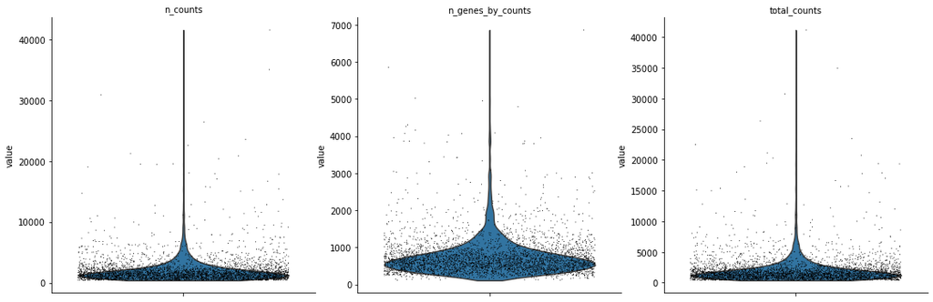

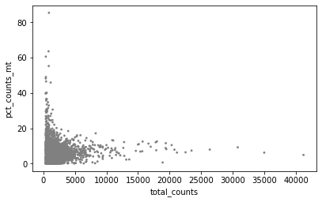

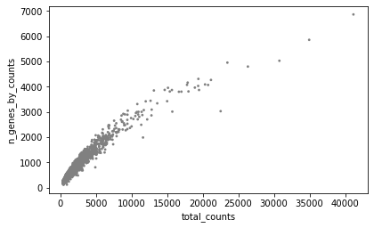

```python
rna_data.var['mt'] = rna_data.var_names.str.startswith('MT-')  # annotate the group of mitochondrial genes as 'mt'
sc.pp.calculate_qc_metrics(rna_data, qc_vars=['mt'], percent_top=None, log1p=False, inplace=True)

sc.pl.violin(rna_data, ['n_counts','n_genes_by_counts','total_counts'], jitter = 0.4, multi_panel = True)
sc.pl.scatter(rna_data, x='total_counts', y='pct_counts_mt')
sc.pl.scatter(rna_data, x='total_counts', y='n_genes_by_counts')
```

Subset cells by %mitochondrial reads, and also remove cells with a huge number of genes since these may dublets or technical anomolies.

```python
rna_data = rna_data[rna_data.obs.pct_counts_mt < 15, :]
rna_data = rna_data[rna_data.obs.n_genes_by_counts < 3000, :]
```

## Feature Selection

With QC, complete, we need to perform feature selection to identify two groups of genes. The first is

- Genes with high enough expression warrant study, modeling, and imputation

Essentially genes that meat a minimum `mean_expression` threshold. The second group is a subset of the first, and contains

- Genes with highly dispersed expression

These genes are more likely to follow interesting patterns of dynamic response and regulation. SCIPM will learn module relationships and impute expression patterns in all genes in the first group, but will use only the second group of genes' expression in mapping expression to latent module compositions. This reduces training time and ensures that modules follow dynamic changes in expression instead of basal trends that are more likely to arrise in non-deviant genes.

**Important:** Freeze the state of the andata here to preserve raw counts

```python
rna_data.raw = rna_data # first, freeze the anndata's state in raw counts
```

```python
sc.pp.normalize_total(rna_data, target_sum=1e4) #normalize and log
sc.pp.log1p(rna_data)
```

Next, find genes that meet scanpy's default `min_mean` requirement, which is reasonable set.

Here, reduce the `min_disp` parameter so that genes that are expressed, but not necessarily variable, are included. All genes flagged with "highly_variable" will be modeled by scIPM.

```python
sc.pp.highly_variable_genes(rna_data, min_disp = -0.1)
```

With the first group of genes selected, choose a subset of them which will be used as features for the encoder. For this, simply set a higher threshold for dispersion. Add a `is_feature` column to the `.vars` dataframe which flags genes that have a `dispersions_norm` greater than 0.8. This particular threshold should be adjusted so that between 1000 and 2000 dispersed genes are used as features.

```python
rna_data.var['is_feature'] = rna_data.var.dispersions_norm > 0.8
```

**Important:** Restore the raw count matrix from the `.raw` attribute, then subset the counts to genes flagged `highly_variable`, or all genes that passed the minimum expression test.

```python
rna_data.X = rna_data.raw.X

rna_data = rna_data[:, rna_data.var.highly_variable]
```

## Hyperparameter Tuning

Now move on to hyperparameter tuning, which seeks to find the most optimal model to describe your data. Kladi utilizes iterative Bayesian Optimization with aggressive pruning to try to converge to the best model in the shortest possible time. The basic workflow is

1. Tune learning rate boundary
2. Iteratively optimize model hyperparameters on training set
3. Select best model trained using validation set

First, separate cells into training and validation sets using `sklearn.model_selection.train_test_split`. The training and testing-set size should be adjusted depending on the size of the dataset and should maximize the proportion of cells in the training set while still providing a reliable evaluation of model quality.

```python
train_expr, test_expr = train_test_split(rna_data.X, train_size = 0.8, random_state = 2556)
```

Next, instantiate an `ExpressionTrainer`. The two arguments that must provide are the

- `features`, a list or numpy array of gene names
- `highly_variable`, a boolean mask the same length as the features list, where highly-variable genes that will be used as features for the encoder are flagged with `True`

```python
estimator = ExpressionTrainer(features = np.array(rna_data.var_names),
                  highly_variable = rna_data.var.is_feature.values)
```

After instantiating a trainer, run the `tune_learning_rate_bounds` function to identify the minimum and maximum learning rates appropriate for the dataset. This function gradually increases the learning rate of the optimizer while monitoring the loss. The optimal boundaries for the learning rate are at the start and end of region of the loss curve with the greatest decreasing slope.

```python
estimator.tune_learning_rate_bounds(train_expr, num_epochs = 5, eval_every = 10)
```

```
(0.0009325715837037386, 0.1430019603506025)
```

One may also directly set the learning rates with the `ExpressionTrainer.set_learning_rates` function.

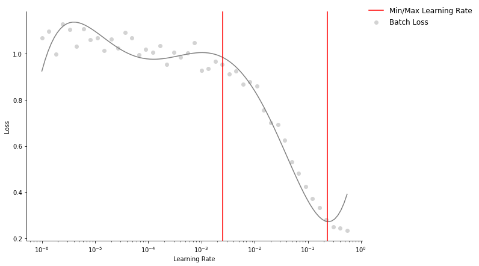

```python
estimator.trim_learning_rate_bounds(1, 0)
estimator.plot_learning_rate_bounds()
```

With the learning rate set, use Bayesian Optimization to rune the remaining hyperparameters:

- num_modules: the number of moduels to learn from the data, extremely important to understanding real biological variation
- dropout: regularization of the encoder network
- num_epochs: length of training routine
- batch_size: mini-batch size of stochastic Adam optimizer

The tuner updates a histogram with the number of modules chosen for each trial. When the optimizer repeatedly chooses similar `num_modules` hyperparamters, this is a sign it is converging closer to the optimal model. The process may be stopped after a number of iterations, or by esc-I-I to interrupt the process. This will end optimization and save results.

```python
study = estimator.tune_hyperparameters(train_expr.copy())
```

```
Trials finished: 64 | Best trial: 43 | Best score: 2.1757e-01

Modules | Trials (number is #folds tested)
      5 | 5 3 1 1
      6 | 1 1 1 1 1
      7 | 5 5 5 1 3 1 1
      8 | 3 1 3 1 1 3
      9 | 5 1 5 3 1 5 1 5 5 1 1
     10 | 3 5 1 5 5 1 5
     11 | 3 5 1 5 1
     12 | 3 1 5
     13 | 1 1 1
     14 | 1
     15 | 3 3 1
     17 | 1
     18 | 1
     20 | 1
     22 | 5
     23 | 1
     24 | 1
     27 | 1
     38 | 1
     53 | 1

Trial Information:
Trial #0   | completed, score: 2.2120e-01 | params: {'num_modules': 22, 'batch_size': 128, 'encoder_dropout': 0.08242138974805993, 'num_epochs': 24, 'seed': 1962878913}
Trial #1   | completed, score: 2.1833e-01 | params: {'num_modules': 5, 'batch_size': 64, 'encoder_dropout': 0.2396864600494837, 'num_epochs': 31, 'seed': 2144373191}
Trial #2   | completed, score: 2.1784e-01 | params: {'num_modules': 7, 'batch_size': 64, 'encoder_dropout': 0.026511986055858736, 'num_epochs': 22, 'seed': 2067730395}
Trial #3   | pruned at step: 3            | params: {'num_modules': 5, 'batch_size': 32, 'encoder_dropout': 0.06010452622456072, 'num_epochs': 33, 'seed': 320028794}
Trial #4   | pruned at step: 1            | params: {'num_modules': 38, 'batch_size': 32, 'encoder_dropout': 0.047441768632954184, 'num_epochs': 32, 'seed': 4148136245}
Trial #5   | pruned at step: 1            | params: {'num_modules': 23, 'batch_size': 32, 'encoder_dropout': 0.142868561604981, 'num_epochs': 30, 'seed': 3724803561}
Trial #6   | pruned at step: 1            | params: {'num_modules': 24, 'batch_size': 64, 'encoder_dropout': 0.019707029866746138, 'num_epochs': 32, 'seed': 1767928698}
Trial #7   | pruned at step: 3            | params: {'num_modules': 15, 'batch_size': 64, 'encoder_dropout': 0.22492275542641288, 'num_epochs': 22, 'seed': 2403870987}
Trial #8   | pruned at step: 3            | params: {'num_modules': 10, 'batch_size': 64, 'encoder_dropout': 0.0776732098379506, 'num_epochs': 24, 'seed': 3349825079}
Trial #9   | pruned at step: 3            | params: {'num_modules': 11, 'batch_size': 32, 'encoder_dropout': 0.16735857155053852, 'num_epochs': 26, 'seed': 2532030062}
Trial #10  | completed, score: 2.1788e-01 | params: {'num_modules': 7, 'batch_size': 128, 'encoder_dropout': 0.2978836088039605, 'num_epochs': 39, 'seed': 2037411891}
Trial #11  | completed, score: 2.1792e-01 | params: {'num_modules': 7, 'batch_size': 128, 'encoder_dropout': 0.29420112460401726, 'num_epochs': 40, 'seed': 1590795410}
Trial #12  | pruned at step: 3            | params: {'num_modules': 8, 'batch_size': 128, 'encoder_dropout': 0.12321814252477711, 'num_epochs': 40, 'seed': 2054599470}
Trial #13  | pruned at step: 1            | params: {'num_modules': 5, 'batch_size': 128, 'encoder_dropout': 0.2926976520040703, 'num_epochs': 20, 'seed': 1719701719}
Trial #14  | pruned at step: 1            | params: {'num_modules': 7, 'batch_size': 64, 'encoder_dropout': 0.1917855909845501, 'num_epochs': 36, 'seed': 3938793071}
```

[output cut: 34 more lines]

```
Trial #49  | pruned at step: 1            | params: {'num_modules': 12, 'batch_size': 64, 'encoder_dropout': 0.15468392608774412, 'num_epochs': 34, 'seed': 1671731908}
Trial #50  | pruned at step: 1            | params: {'num_modules': 14, 'batch_size': 64, 'encoder_dropout': 0.17852418868145795, 'num_epochs': 32, 'seed': 3591213543}
Trial #51  | pruned at step: 1            | params: {'num_modules': 10, 'batch_size': 64, 'encoder_dropout': 0.14586654757027778, 'num_epochs': 29, 'seed': 1602447721}
Trial #52  | pruned at step: 1            | params: {'num_modules': 8, 'batch_size': 64, 'encoder_dropout': 0.16704765172291475, 'num_epochs': 27, 'seed': 361880847}
Trial #53  | pruned at step: 1            | params: {'num_modules': 6, 'batch_size': 64, 'encoder_dropout': 0.11112936966046322, 'num_epochs': 30, 'seed': 881998067}
Trial #54  | pruned at step: 1            | params: {'num_modules': 7, 'batch_size': 64, 'encoder_dropout': 0.13000187242707179, 'num_epochs': 26, 'seed': 4238689834}
Trial #55  | completed, score: 2.1760e-01 | params: {'num_modules': 10, 'batch_size': 64, 'encoder_dropout': 0.1773476873677264, 'num_epochs': 31, 'seed': 2662312188}
Trial #56  | completed, score: 2.1782e-01 | params: {'num_modules': 12, 'batch_size': 64, 'encoder_dropout': 0.15674095609337468, 'num_epochs': 35, 'seed': 2506156415}
Trial #57  | completed, score: 2.1772e-01 | params: {'num_modules': 9, 'batch_size': 64, 'encoder_dropout': 0.176929365471849, 'num_epochs': 31, 'seed': 3127708157}
Trial #58  | pruned at step: 1            | params: {'num_modules': 6, 'batch_size': 64, 'encoder_dropout': 0.18590635829814223, 'num_epochs': 32, 'seed': 3640202356}
Trial #59  | pruned at step: 3            | params: {'num_modules': 8, 'batch_size': 128, 'encoder_dropout': 0.034590965961307674, 'num_epochs': 36, 'seed': 1146938458}
Trial #60  | completed, score: 2.1764e-01 | params: {'num_modules': 9, 'batch_size': 64, 'encoder_dropout': 0.07157944422707452, 'num_epochs': 35, 'seed': 805363870}
Trial #61  | pruned at step: 1            | params: {'num_modules': 9, 'batch_size': 64, 'encoder_dropout': 0.07545847747972005, 'num_epochs': 37, 'seed': 3069757599}
Trial #62  | pruned at step: 1            | params: {'num_modules': 7, 'batch_size': 64, 'encoder_dropout': 0.20060689152104288, 'num_epochs': 33, 'seed': 2467548189}
Trial #63  | pruned at step: 1            | params: {'num_modules': 9, 'batch_size': 64, 'encoder_dropout': 0.08371876713311742, 'num_epochs': 39, 'seed': 1291970473}
```

```
WARNING:kladi.matrix_models.scipm_base:Interrupted training.
```

This function returns an `optuna` study, for which you can see methods and visualization methods here: [Optuna Study](https://optuna.readthedocs.io/en/stable/reference/generated/optuna.study.Study.html#optuna.study.Study)

The best models trained in the procedure above must now be retrained with all the training data, and compared on how well they minimize test-set loss. The best model from this final comparison is then fit again using all data and returned to the user. All of this is performed by the `ExpressionTrainer.select_best_model` function. Changing `top_n_models` changes how many models from the optimization procedure will be compared for validation set loss.

```python
model = estimator.select_best_model(train_expr, test_expr, top_n_models = 5)
```

```
INFO:root:Training model with parameters: {'num_modules': 10, 'batch_size': 64, 'encoder_dropout': 0.17186290932951004, 'num_epochs': 29, 'seed': 1392224450}
INFO:root:Score: 2.14799e-01
INFO:root:Training model with parameters: {'num_modules': 10, 'batch_size': 64, 'encoder_dropout': 0.1773476873677264, 'num_epochs': 31, 'seed': 2662312188}
INFO:root:Score: 2.14877e-01
INFO:root:Training model with parameters: {'num_modules': 9, 'batch_size': 64, 'encoder_dropout': 0.1354554213520453, 'num_epochs': 28, 'seed': 60025027}
INFO:root:Score: 2.14850e-01
INFO:root:Training model with parameters: {'num_modules': 9, 'batch_size': 64, 'encoder_dropout': 0.1615287147217766, 'num_epochs': 34, 'seed': 908241052}
INFO:root:Score: 2.15023e-01
INFO:root:Training model with parameters: {'num_modules': 9, 'batch_size': 64, 'encoder_dropout': 0.07157944422707452, 'num_epochs': 35, 'seed': 805363870}
INFO:root:Score: 2.14888e-01
INFO:root:Set parameters to best combination: {'num_modules': 10, 'batch_size': 64, 'encoder_dropout': 0.17186290932951004, 'num_epochs': 29, 'seed': 1392224450}
INFO:root:Training model with all data.
```

The result of this function is an `ExpressionModel` object which contains the methods needed for downstream analysis of the discovered modules. Now is a good time to save the model. The trainer object implements the `save` function, which simply takes a file name and saves the parameters and weights needed to recreate the best model.

```python
estimator.save('data/mouse_prostate/best_model.pth')
```

To reload the model later, simply use:

```
    model = ExpressionTrainer.load('data/mouse_prostate/best_model.pth')
```

## Using model

With the trained model, there are three main functions we can use to represent and visualize the data:

```python
model = ExpressionTrainer.load('data/mouse_prostate/best_model.pth') # load model
```

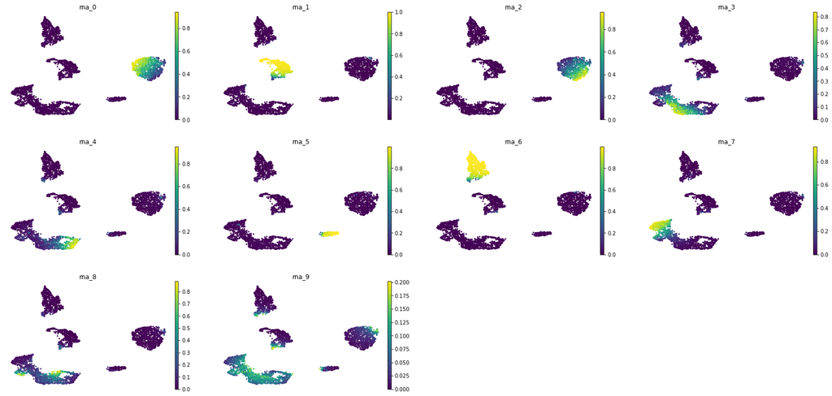

```python
rna_topic_names = ['rna_{}'.format(str(i)) for i in range(model.num_topics)] # get a column name for each topic

rna_data.obs[rna_topic_names] = model.predict(rna_data.X) # predict topic compositions and add them to "obs" columns

rna_data.layers['imputed'] = model.impute(model.predict(rna_data.X)) # impute gene expression to a new layer in the anndata

rna_data.obsm['umap_features'] = model.get_UMAP_features(rna_data.X) # get real-space embedding of cells

sc.pp.neighbors(rna_data, use_rep = 'umap_features') # run scanpy's UMAP
sc.tl.umap(rna_data, min_dist = 0.3, negative_sample_rate = 5)

sc.pl.umap(rna_data, color = rna_topic_names, color_map = 'viridis', frameon = False) # visualize topics
```

# Accessibility Modeling

## Preprocessing

I used MAESTRO to convert the fragment file into a binary peak-count matrix, then filtered for cells with greater than 400 accessible regions.

```python
from kladi.matrix_models.estimator import AccessibilityTrainer, ExpressionTrainer

from sklearn.model_selection import train_test_split, ShuffleSplit
import scanpy as sc
import anndata
import numpy as np
import logging
logging.basicConfig(level=logging.INFO)
```

```python
atac_data = anndata.read_h5ad('data/mouse_prostate/atac_data.h5ad')
atac_data.var[['chr','start','end']] = atac_data.var.id.str.split('_', expand = True) # make chrom, start, and end columns, alternatively, make a column of <chr>:<start>-<end>
```

## Feature selection

Feature selection in scATAC-seq is not as well defined as in scRNA-seq, where dispersed genes are well-established as good features for differentiating cell states. No such analogue is accepted in scATAC-seq so there are two options for choosing features for the encoder network:

1. Use every peak
2. If memory requires or there are many peaks in the sample (>150K), randomly downsample to ~100K peaks.

In this example, I do not subset the features of the accessibility model.

## Hyperparameter selection

The procedure and interface for hyperparameter selection are identical, except we use `AccessibilityTrainer` instead of `ExpressionTrainer`. Instead of passing gene names to the `features` argument, instead pass the peak locations in the format:

```
[[chr, start, end], ...]
```

One can also pass a list of strings in the format:

```
["<chr>:<start>-<end>", ...]
```

```python
train_acc, test_acc = train_test_split(atac_data.X, random_state = 2556, train_size = 0.8) #make train and validation set
```

```python
atac_estimator = AccessibilityTrainer(features = atac_data.var[['chr','start','end']].values.tolist()) # instantiate estimator, leaving highly_variable argument as None
```

```python
atac_estimator.tune_learning_rate_bounds(train_acc, eval_every = 10, num_epochs = 7) # increase the number of epochs of the test to get more sampled points
```

```
(4.261911782300387e-06, 0.08590683144559928)
```

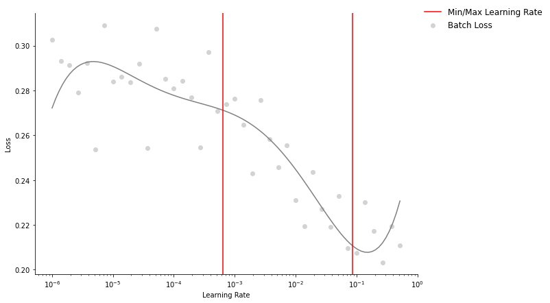

```python
atac_estimator.trim_learning_rate_bounds(5, 0.5) #trim in lower bound aggressively
atac_estimator.plot_learning_rate_bounds()
```

```python
atac_study = atac_estimator.tune_hyperparameters(train_acc)
```

```
Trials finished: 161 | Best trial: 53 | Best score: 2.0560e-01

Modules | Trials (number is #folds tested)
      5 | 1 1
      6 | 1
      8 | 0 0
      9 | 5 0 5
     10 | 1 0
     11 | 0 1 0
     12 | 1 1 3 1 3
     13 | 0 1 0 1 3 1 5
     14 | 1 3 5 3 1 3 1 1 3 1
     15 | 5 0 5 1 5 5 1 0 1 0 1 1 1 0 3 3
     16 | 5 3 5 5 0 5 1 1 1 3 3 3 1 5 1 1 1
     17 | 1 1 5 5 5 5 5 1 3 5 5 1 1 1 3 1 1 3 5
     18 | 1 1 1 3 1 5 1 5 1 1 3 5 1 1 1
     19 | 5 1 1 1 5 1 3 1 3 5 3 1 1 1
     20 | 1 0 5 3 1 1 1 1 1 5 1 1
     21 | 5 5 3 1 3 0 1
     22 | 1 3 1 1 1 3
     23 | 3 1 1
     24 | 1 0 1
     25 | 0 1
     26 | 3
     27 | 1 1
     29 | 1 1
     30 | 0
     32 | 1
     34 | 1
     38 | 0
     39 | 1
     49 | 1
     52 | 0

Trial Information:
Trial #0   | completed, score: 2.0596e-01 | params: {'num_modules': 9, 'batch_size': 32, 'encoder_dropout': 0.10389355044650528, 'num_epochs': 28, 'seed': 228295817}
Trial #1   | pruned at step: 0            | params: {'num_modules': 9, 'batch_size': 64, 'encoder_dropout': 0.12254635139845542, 'num_epochs': 31, 'seed': 1218731039}
Trial #2   | completed, score: 2.0586e-01 | params: {'num_modules': 9, 'batch_size': 32, 'encoder_dropout': 0.12588953117923532, 'num_epochs': 39, 'seed': 2515659408}
Trial #3   | pruned at step: 0            | params: {'num_modules': 52, 'batch_size': 128, 'encoder_dropout': 0.2889427071470159, 'num_epochs': 34, 'seed': 2281583406}
Trial #4   | pruned at step: 0            | params: {'num_modules': 8, 'batch_size': 64, 'encoder_dropout': 0.053870229594672754, 'num_epochs': 23, 'seed': 4016119507}
```

[output cut: 141 more lines]

```
Trial #146 | pruned at step: 3            | params: {'num_modules': 22, 'batch_size': 32, 'encoder_dropout': 0.03815665014685657, 'num_epochs': 29, 'seed': 2030732230}
Trial #147 | pruned at step: 1            | params: {'num_modules': 19, 'batch_size': 32, 'encoder_dropout': 0.057572365439320455, 'num_epochs': 29, 'seed': 3954254318}
Trial #148 | pruned at step: 1            | params: {'num_modules': 17, 'batch_size': 32, 'encoder_dropout': 0.07857539260203023, 'num_epochs': 30, 'seed': 3179813595}
Trial #149 | pruned at step: 1            | params: {'num_modules': 16, 'batch_size': 32, 'encoder_dropout': 0.04864866600797294, 'num_epochs': 32, 'seed': 1907508700}
Trial #150 | pruned at step: 1            | params: {'num_modules': 21, 'batch_size': 32, 'encoder_dropout': 0.040600182836535575, 'num_epochs': 32, 'seed': 3007089249}
Trial #151 | pruned at step: 1            | params: {'num_modules': 18, 'batch_size': 32, 'encoder_dropout': 0.013736415624482655, 'num_epochs': 30, 'seed': 3201492304}
Trial #152 | pruned at step: 3            | params: {'num_modules': 17, 'batch_size': 32, 'encoder_dropout': 0.02260311094511795, 'num_epochs': 30, 'seed': 1386249212}
Trial #153 | pruned at step: 1            | params: {'num_modules': 5, 'batch_size': 32, 'encoder_dropout': 0.2973128959155331, 'num_epochs': 31, 'seed': 720719870}
Trial #154 | pruned at step: 1            | params: {'num_modules': 14, 'batch_size': 32, 'encoder_dropout': 0.03167673086875623, 'num_epochs': 31, 'seed': 3789882838}
Trial #155 | pruned at step: 1            | params: {'num_modules': 19, 'batch_size': 32, 'encoder_dropout': 0.035320836519760465, 'num_epochs': 31, 'seed': 575705489}
Trial #156 | pruned at step: 3            | params: {'num_modules': 15, 'batch_size': 32, 'encoder_dropout': 0.054298559662832875, 'num_epochs': 36, 'seed': 826714973}
Trial #157 | pruned at step: 1            | params: {'num_modules': 16, 'batch_size': 32, 'encoder_dropout': 0.010265330124322538, 'num_epochs': 31, 'seed': 1742631409}
Trial #158 | completed, score: 2.0564e-01 | params: {'num_modules': 17, 'batch_size': 32, 'encoder_dropout': 0.027468898854720585, 'num_epochs': 30, 'seed': 1195997241}
Trial #159 | pruned at step: 1            | params: {'num_modules': 18, 'batch_size': 32, 'encoder_dropout': 0.028371903013011762, 'num_epochs': 29, 'seed': 1472097351}
Trial #160 | pruned at step: 3            | params: {'num_modules': 15, 'batch_size': 32, 'encoder_dropout': 0.04040084039964536, 'num_epochs': 32, 'seed': 1489168809}
```

```
WARNING:kladi.matrix_models.scipm_base:Interrupted training.
```

```python
atac_model = atac_estimator.select_best_model(train_acc, test_acc)
```

```
INFO:root:Training model with parameters: {'num_modules': 16, 'batch_size': 32, 'encoder_dropout': 0.023435233664846504, 'num_epochs': 33, 'seed': 2862597996}
INFO:root:Score: 2.01356e-01
INFO:root:Training model with parameters: {'num_modules': 17, 'batch_size': 32, 'encoder_dropout': 0.05037912250709933, 'num_epochs': 32, 'seed': 154455071}
INFO:root:Score: 2.01183e-01
INFO:root:Training model with parameters: {'num_modules': 20, 'batch_size': 32, 'encoder_dropout': 0.03362340108391326, 'num_epochs': 30, 'seed': 2136284932}
INFO:root:Score: 2.01352e-01
INFO:root:Training model with parameters: {'num_modules': 19, 'batch_size': 32, 'encoder_dropout': 0.04236474409721123, 'num_epochs': 37, 'seed': 3655390847}
INFO:root:Score: 2.01173e-01
INFO:root:Training model with parameters: {'num_modules': 18, 'batch_size': 32, 'encoder_dropout': 0.050939973516588494, 'num_epochs': 32, 'seed': 2269889261}
INFO:root:Score: 2.01172e-01
INFO:root:Set parameters to best combination: {'num_modules': 18, 'batch_size': 32, 'encoder_dropout': 0.050939973516588494, 'num_epochs': 32, 'seed': 2269889261}
INFO:root:Training model with all data.
```

```python
atac_estimator.save('data/mouse_prostate/best_atac_model.pth')
```

## Using accessibility model

The accessibility model has similar functions as the expression model for representation, except `impute` is not available due to the memory constrains of imputing every peak in every cell with a dense probablility.

```python
atac_model = AccessibilityTrainer.load('data/mouse_prostate/best_atac_model.pth')
```

```python
atac_topic_names = ['atac_{}'.format(str(i)) for i in range(atac_model.num_topics)] # get a column name for each topic

atac_data.obs[atac_topic_names] = atac_model.predict(atac_data.X) # predict topic compositions and add them to "obs" columns

atac_data.obsm['umap_features'] = atac_model.get_UMAP_features(atac_data.X) # get real-space embedding of cells
```

```python
sc.pp.neighbors(atac_data, use_rep = 'umap_features') # run scanpy's UMAP
sc.tl.umap(atac_data, min_dist = 0.3, negative_sample_rate = 5)
```

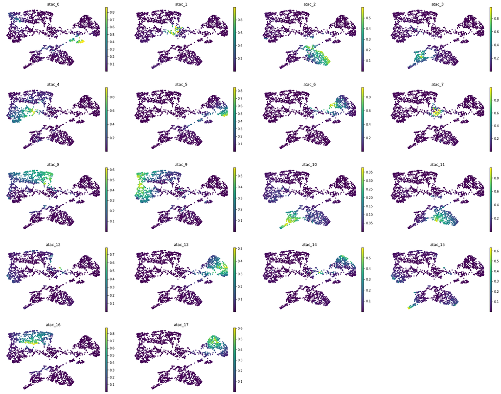

```python
sc.pl.umap(atac_data, color = atac_topic_names, color_map = 'viridis', frameon = False) # visualize topics
```

## Creating joint representation

To create the joint representation, we need to find cells that passed QC for both assays by intersecting the cell barcodes. Unfortunately for this assay, only 1300 cells passed both scRNA and scATAC QC thresholds.

```python
overlapping_barcodes = np.intersect1d(rna_data.obs_names, atac_data.obs_names) # overlap barcodes of cells that passed both assays' QC

overlapping_barcodes.shape
```

```
(1300,)
```

If I look at what sorts of cells are shared between the two assays, they appear to be evenly-mixed in between major cell types in the RNA-seq representation (bottom), but according to the ATAC-seq representation (top), we will lose a major cell population in the joint representation. This cell type may not be captured well by scRNA-seq or may have too few transcripts to pass QC.

```
... storing 'shared_cell' as categorical
```

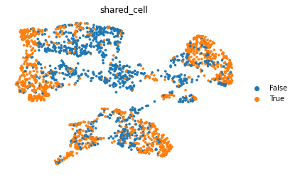

```
... storing 'shared_cell' as categorical
```

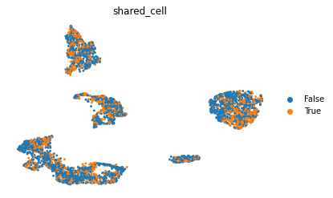

```python
atac_data.obs['shared_cell'] = atac_data.obs_names.isin(overlapping_barcodes).astype(str)
rna_data.obs['shared_cell'] = rna_data.obs_names.isin(overlapping_barcodes).astype(str)
sc.pl.umap(atac_data, color = 'shared_cell', color_map = 'Set2', frameon = False)
sc.pl.umap(rna_data, color = 'shared_cell', color_map = 'Set2', frameon = False)
```

```python
shared_rna, shared_atac = rna_data[overlapping_barcodes].copy(), atac_data[overlapping_barcodes].copy() # subset dataframes using same cells

shared_rna.obsm['joint_features'] = np.hstack([shared_rna.obsm['umap_features'], shared_atac.obsm['umap_features']]) # create joint features by concatenating RNA and ATAC UMAP features

shared_atac.obsm['joint_features'] = shared_rna.obsm['joint_features'] # share joint features with scATAC-seq anndata
```

Since I lost a significant portion of cells by joining the representations, this UMAP loses some clarity, but it still shows separated cell types. The RNA-seq topics still appear coherent with respect ot the cell representations.

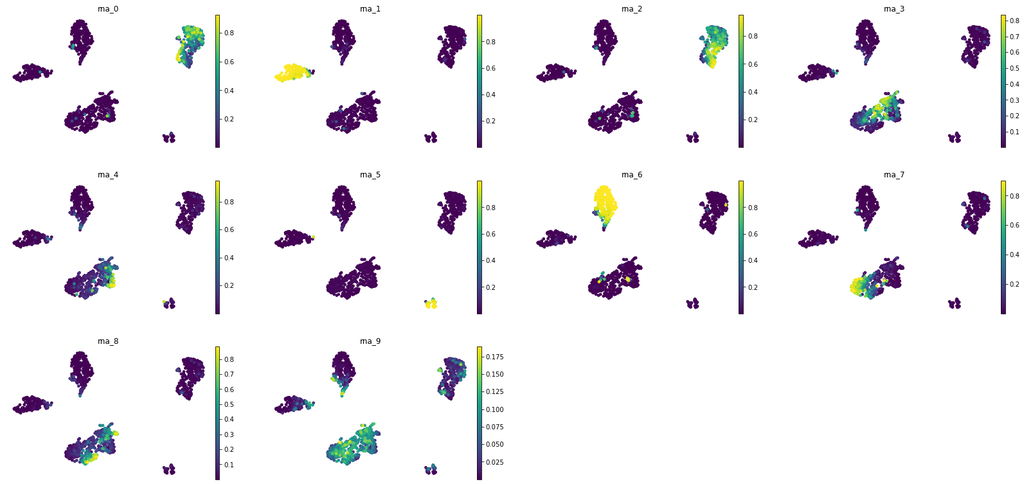

```python
sc.pp.neighbors(shared_rna, use_rep = 'joint_features') # run scanpy's UMAP
sc.tl.umap(shared_rna, min_dist = 0.3, negative_sample_rate = 5)

sc.pl.umap(shared_rna, color = rna_topic_names, frameon=False)
```

Continue with previous analysis notebook ...